# Final Report for Intro to Data Science

#Introduction# My project will answer my questions and confirm or deny my predictions. I predict that action and drama will be the most popular genres and it will be because of the actors depending on the point in time which in my test will be around the time of 2005-2010. First lets Load some stuff from our library

#Prerequistest

```r
library(tidyverse)
library(ggplot2)
library(scales)
library(dplyr)
```

#Data When we go to the movies we are influenced by the actors or genre. This will effect the outgoing total of income but what genre ends up being the end winner? The data set i will be using is as follows:

```r
Movies <- read_csv(file = "../data/IMDB_movies.csv")
Movies
```

| Rank | Title | Genre | Description | Director | Actors | Year | Runtime (Minutes) | Rating | Votes | Revenue (Millions) | Metascore |
| --- | --- | --- | --- | --- | --- | --- | --- | --- | --- | --- | --- |
| 1 | Guardians of the Galaxy | Action,Adventure,Sci-Fi | A group of intergalactic criminals are forced to work together to stop a fanatical warrior from taking control of the universe. | James Gunn | Chris Pratt, Vin Diesel, Bradley Cooper, Zoe Saldana | 2014 | 121 | 8.1 | 757074 | 333.13 | 76 |
| 2 | Prometheus | Adventure,Mystery,Sci-Fi | Following clues to the origin of mankind, a team finds a structure on a distant moon, but they soon realize they are not alone. | Ridley Scott | Noomi Rapace, Logan Marshall-Green, Michael Fassbender, Charlize Theron | 2012 | 124 | 7.0 | 485820 | 126.46 | 65 |
| 3 | Split | Horror,Thriller | Three girls are kidnapped by a man with a diagnosed 23 distinct personalities. They must try to escape before the apparent emergence of a frightful new 24th. | M. Night Shyamalan | James McAvoy, Anya Taylor-Joy, Haley Lu Richardson, Jessica Sula | 2016 | 117 | 7.3 | 157606 | 138.12 | 62 |
| 4 | Sing | Animation,Comedy,Family | In a city of humanoid animals, a hustling theater impresario's attempt to save his theater with a singing competition becomes grander than he anticipates even as its finalists' find that their lives w… | Christophe Lourdelet | Matthew McConaughey,Reese Witherspoon, Seth MacFarlane, Scarlett Johansson | 2016 | 108 | 7.2 | 60545 | 270.32 | 59 |
| 5 | Suicide Squad | Action,Adventure,Fantasy | A secret government agency recruits some of the most dangerous incarcerated super-villains to form a defensive task force. Their first mission: save the world from the apocalypse. | David Ayer | Will Smith, Jared Leto, Margot Robbie, Viola Davis | 2016 | 123 | 6.2 | 393727 | 325.02 | 40 |
| 6 | The Great Wall | Action,Adventure,Fantasy | European mercenaries searching for black powder become embroiled in the defense of the Great Wall of China against a horde of monstrous creatures. | Yimou Zhang | Matt Damon, Tian Jing, Willem Dafoe, Andy Lau | 2016 | 103 | 6.1 | 56036 | 45.13 | 42 |
| 7 | La La Land | Comedy,Drama,Music | A jazz pianist falls for an aspiring actress in Los Angeles. | Damien Chazelle | Ryan Gosling, Emma Stone, Rosemarie DeWitt, J.K. Simmons | 2016 | 128 | 8.3 | 258682 | 151.06 | 93 |
| 8 | Mindhorn | Comedy | A has-been actor best known for playing the title character in the 1980s detective series "Mindhorn" must work with the police when a serial killer says that he will only speak with Detective Mindhorn… | Sean Foley | Essie Davis, Andrea Riseborough, Julian Barratt,Kenneth Branagh | 2016 | 89 | 6.4 | 2490 | NA | 71 |
| 9 | The Lost City of Z | Action,Adventure,Biography | A true-life drama, centering on British explorer Col. Percival Fawcett, who disappeared while searching for a mysterious city in the Amazon in the 1920s. | James Gray | Charlie Hunnam, Robert Pattinson, Sienna Miller, Tom Holland | 2016 | 141 | 7.1 | 7188 | 8.01 | 78 |
| 10 | Passengers | Adventure,Drama,Romance | A spacecraft traveling to a distant colony planet and transporting thousands of people has a malfunction in its sleep chambers. As a result, two passengers are awakened 90 years early. | Morten Tyldum | Jennifer Lawrence, Chris Pratt, Michael Sheen,Laurence Fishburne | 2016 | 116 | 7.0 | 192177 | 100.01 | 41 |

[output cut: 990 more lines]

#Record Data/Findings

Firstly we want to determine what years to look at because alot of movies are produced each year menaing 10 years will be too much to look at, So I will narrow it down by making a graph showing by dots what years had the highest ratings in movies overall. Before all this when i looked at my data table, I was able to see movies recorded from the year of 2006 to 2016.

```r
  Movies2008 <- select(Movies, Year, Rating, Genre) %>%
  arrange(desc(Rating))
Movies2008
```

| Year | Rating | Genre |
| --- | --- | --- |
| 2008 | 9.0 | Action,Crime,Drama |
| 2010 | 8.8 | Action,Adventure,Sci-Fi |
| 2016 | 8.8 | Action,Biography,Drama |
| 2014 | 8.6 | Adventure,Drama,Sci-Fi |
| 2016 | 8.6 | Animation,Drama,Fantasy |
| 2011 | 8.6 | Biography,Comedy,Drama |
| 2006 | 8.5 | Drama,Mystery,Sci-Fi |
| 2006 | 8.5 | Crime,Drama,Thriller |
| 2012 | 8.5 | Action,Thriller |
| 2014 | 8.5 | Drama,Music |

[output cut: 990 more lines]

```r
Movies2008 %>%
  filter(Year == 2008)
```

| Year | Rating | Genre |
| --- | --- | --- |
| 2008 | 9.0 | Action,Crime,Drama |
| 2008 | 8.4 | Animation,Adventure,Family |
| 2008 | 8.2 | Drama |
| 2008 | 8.0 | Drama |
| 2008 | 7.9 | Action,Adventure,Sci-Fi |
| 2008 | 7.9 | Comedy,Crime,Drama |
| 2008 | 7.8 | Action,Thriller |
| 2008 | 7.8 | Drama,Fantasy,Romance |
| 2008 | 7.8 | Drama,War |
| 2008 | 7.8 | Biography,Drama,Mystery |

[output cut: 42 more lines]

[figure not shown]

```r
  ggplot(data = Movies2008) +
  geom_point(aes(x = Genre, y = Rating ))
```

The table shows that the highest rated movie is in the Genre category of: Action, Crime, and Drama. Now to see if there’s a second runner up. I will determine the next highest rated movie in a different year.

```r
Toprate <- select(Movies,Year, Rating, Genre, Title) %>%
  arrange(desc(Rating))
Toprate
```

| Year | Rating | Genre | Title |
| --- | --- | --- | --- |
| 2008 | 9.0 | Action,Crime,Drama | The Dark Knight |
| 2010 | 8.8 | Action,Adventure,Sci-Fi | Inception |
| 2016 | 8.8 | Action,Biography,Drama | Dangal |
| 2014 | 8.6 | Adventure,Drama,Sci-Fi | Interstellar |
| 2016 | 8.6 | Animation,Drama,Fantasy | Kimi no na wa |
| 2011 | 8.6 | Biography,Comedy,Drama | The Intouchables |
| 2006 | 8.5 | Drama,Mystery,Sci-Fi | The Prestige |
| 2006 | 8.5 | Crime,Drama,Thriller | The Departed |
| 2012 | 8.5 | Action,Thriller | The Dark Knight Rises |
| 2014 | 8.5 | Drama,Music | Whiplash |

[output cut: 990 more lines]

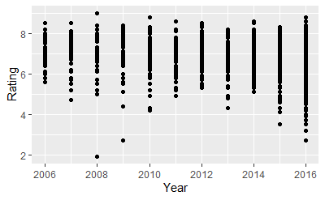

```r
ggplot(data = Toprate) +
  geom_point(aes(x = Year, y = Rating))
```

The second highest ranked movie (based on its tier in the table) is a movie called “Inception”. This movie is rated with an 8.8 In the Genre category of: Action, Adventure, and Sci-Fi. The other movie below that was also rated an 8.8 was Dangal which is in the Genre category: Action, Biography, and Drama.

1 Last thing I would like to investigate is what the lowest rated movie in 2008 is because on the graph it is very apparent. We can quickly re-use the command above and make it go from lowest Rating up to see what it is.

```r
Toprate <- select(Movies,Year, Rating, Genre, Title) %>%
  arrange(Rating)
Toprate
```

| Year | Rating | Genre | Title |
| --- | --- | --- | --- |
| 2008 | 1.9 | Comedy | Disaster Movie |
| 2016 | 2.7 | Horror | Don't Fuck in the Woods |
| 2009 | 2.7 | Action,Adventure,Fantasy | Dragonball Evolution |
| 2016 | 3.2 | Fantasy,Horror,Thriller | Tall Men |
| 2016 | 3.5 | Crime,Drama | The Intent |
| 2015 | 3.5 | Action,Horror,Thriller | Wrecker |
| 2016 | 3.7 | Drama | The Last Face |
| 2016 | 3.7 | Horror | Satanic |
| 2016 | 3.9 | Drama,Horror,Thriller | The Disappointments Room |
| 2016 | 3.9 | Horror | The Black Room |

[output cut: 990 more lines]

#Conclusion

After all this further Investigation/Research on my data I can see That Action ad Drama based movies are the Most Popular types of movies (Based on 2008 1012, and 2014 ) and that in 2008 a movie hit all time low against all other movies in this dataset with a 1.9. :(